# Risk Factor Analysis

## Outcome Variable

**Outcome Variable:** wast_rec90d

## Predictor Variables

**Intervention Variable:** impfloor

**Adjustment Set:**

unadjusted

## Stratifying Variables

The analysis was stratified on these variable(s):

- agecat
- studyid
- country

## Data Summary

| agecat | studyid | country | impfloor | wast_rec90d | n_cell | n |
| --- | --- | --- | --- | --- | --- | --- |
| 0-24 months | ki0047075b-MAL-ED | BANGLADESH | 1 | 0 | 37 | 121 |
| 0-24 months | ki0047075b-MAL-ED | BANGLADESH | 1 | 1 | 73 | 121 |
| 0-24 months | ki0047075b-MAL-ED | BANGLADESH | 0 | 0 | 6 | 121 |
| 0-24 months | ki0047075b-MAL-ED | BANGLADESH | 0 | 1 | 5 | 121 |
| 0-24 months | ki0047075b-MAL-ED | BRAZIL | 1 | 0 | 6 | 24 |
| 0-24 months | ki0047075b-MAL-ED | BRAZIL | 1 | 1 | 18 | 24 |
| 0-24 months | ki0047075b-MAL-ED | BRAZIL | 0 | 0 | 0 | 24 |
| 0-24 months | ki0047075b-MAL-ED | BRAZIL | 0 | 1 | 0 | 24 |
| 0-24 months | ki0047075b-MAL-ED | INDIA | 1 | 0 | 60 | 175 |
| 0-24 months | ki0047075b-MAL-ED | INDIA | 1 | 1 | 101 | 175 |
| 0-24 months | ki0047075b-MAL-ED | INDIA | 0 | 0 | 6 | 175 |
| 0-24 months | ki0047075b-MAL-ED | INDIA | 0 | 1 | 8 | 175 |
| 0-24 months | ki0047075b-MAL-ED | NEPAL | 1 | 0 | 9 | 92 |
| 0-24 months | ki0047075b-MAL-ED | NEPAL | 1 | 1 | 34 | 92 |
| 0-24 months | ki0047075b-MAL-ED | NEPAL | 0 | 0 | 10 | 92 |
| 0-24 months | ki0047075b-MAL-ED | NEPAL | 0 | 1 | 39 | 92 |
| 0-24 months | ki0047075b-MAL-ED | PERU | 1 | 0 | 2 | 34 |
| 0-24 months | ki0047075b-MAL-ED | PERU | 1 | 1 | 5 | 34 |
| 0-24 months | ki0047075b-MAL-ED | PERU | 0 | 0 | 4 | 34 |
| 0-24 months | ki0047075b-MAL-ED | PERU | 0 | 1 | 23 | 34 |
| 0-24 months | ki0047075b-MAL-ED | SOUTH AFRICA | 1 | 0 | 13 | 80 |
| 0-24 months | ki0047075b-MAL-ED | SOUTH AFRICA | 1 | 1 | 64 | 80 |
| 0-24 months | ki0047075b-MAL-ED | SOUTH AFRICA | 0 | 0 | 0 | 80 |
| 0-24 months | ki0047075b-MAL-ED | SOUTH AFRICA | 0 | 1 | 3 | 80 |
| 0-24 months | ki0047075b-MAL-ED | TANZANIA, UNITED REPUBLIC OF | 1 | 0 | 1 | 51 |
| 0-24 months | ki0047075b-MAL-ED | TANZANIA, UNITED REPUBLIC OF | 1 | 1 | 1 | 51 |
| 0-24 months | ki0047075b-MAL-ED | TANZANIA, UNITED REPUBLIC OF | 0 | 0 | 8 | 51 |
| 0-24 months | ki0047075b-MAL-ED | TANZANIA, UNITED REPUBLIC OF | 0 | 1 | 41 | 51 |
| 0-24 months | ki1000108-CMC-V-BCS-2002 | INDIA | 1 | 0 | 78 | 223 |
| 0-24 months | ki1000108-CMC-V-BCS-2002 | INDIA | 1 | 1 | 145 | 223 |

[output cut: 162 more lines]

The following strata were considered:

- agecat: 0-24 months, studyid: ki0047075b-MAL-ED, country: BANGLADESH
- agecat: 0-24 months, studyid: ki0047075b-MAL-ED, country: BRAZIL
- agecat: 0-24 months, studyid: ki0047075b-MAL-ED, country: INDIA
- agecat: 0-24 months, studyid: ki0047075b-MAL-ED, country: NEPAL
- agecat: 0-24 months, studyid: ki0047075b-MAL-ED, country: PERU
- agecat: 0-24 months, studyid: ki0047075b-MAL-ED, country: SOUTH AFRICA
- agecat: 0-24 months, studyid: ki0047075b-MAL-ED, country: TANZANIA, UNITED REPUBLIC OF
- agecat: 0-24 months, studyid: ki1000108-CMC-V-BCS-2002, country: INDIA
- agecat: 0-24 months, studyid: ki1000108-IRC, country: INDIA
- agecat: 0-24 months, studyid: ki1017093-NIH-Birth, country: BANGLADESH
- agecat: 0-24 months, studyid: ki1017093b-PROVIDE, country: BANGLADESH
- agecat: 0-24 months, studyid: ki1017093c-NIH-Crypto, country: BANGLADESH
- agecat: 0-24 months, studyid: ki1113344-GMS-Nepal, country: NEPAL
- agecat: 0-24 months, studyid: ki1114097-CONTENT, country: PERU
- agecat: 0-24 months, studyid: kiGH5241-JiVitA-3, country: BANGLADESH
- agecat: 0-24 months, studyid: kiGH5241-JiVitA-4, country: BANGLADESH
- agecat: 0-6 months, studyid: ki0047075b-MAL-ED, country: BANGLADESH
- agecat: 0-6 months, studyid: ki0047075b-MAL-ED, country: BRAZIL
- agecat: 0-6 months, studyid: ki0047075b-MAL-ED, country: INDIA
- agecat: 0-6 months, studyid: ki0047075b-MAL-ED, country: NEPAL
- agecat: 0-6 months, studyid: ki0047075b-MAL-ED, country: PERU
- agecat: 0-6 months, studyid: ki0047075b-MAL-ED, country: SOUTH AFRICA
- agecat: 0-6 months, studyid: ki0047075b-MAL-ED, country: TANZANIA, UNITED REPUBLIC OF
- agecat: 0-6 months, studyid: ki1000108-CMC-V-BCS-2002, country: INDIA
- agecat: 0-6 months, studyid: ki1000108-IRC, country: INDIA
- agecat: 0-6 months, studyid: ki1017093-NIH-Birth, country: BANGLADESH
- agecat: 0-6 months, studyid: ki1017093b-PROVIDE, country: BANGLADESH
- agecat: 0-6 months, studyid: ki1017093c-NIH-Crypto, country: BANGLADESH
- agecat: 0-6 months, studyid: ki1113344-GMS-Nepal, country: NEPAL
- agecat: 0-6 months, studyid: ki1114097-CONTENT, country: PERU
- agecat: 0-6 months, studyid: kiGH5241-JiVitA-3, country: BANGLADESH
- agecat: 0-6 months, studyid: kiGH5241-JiVitA-4, country: BANGLADESH
- agecat: 6-24 months, studyid: ki0047075b-MAL-ED, country: BANGLADESH
- agecat: 6-24 months, studyid: ki0047075b-MAL-ED, country: BRAZIL
- agecat: 6-24 months, studyid: ki0047075b-MAL-ED, country: INDIA
- agecat: 6-24 months, studyid: ki0047075b-MAL-ED, country: NEPAL
- agecat: 6-24 months, studyid: ki0047075b-MAL-ED, country: PERU
- agecat: 6-24 months, studyid: ki0047075b-MAL-ED, country: SOUTH AFRICA
- agecat: 6-24 months, studyid: ki0047075b-MAL-ED, country: TANZANIA, UNITED REPUBLIC OF
- agecat: 6-24 months, studyid: ki1000108-CMC-V-BCS-2002, country: INDIA
- agecat: 6-24 months, studyid: ki1000108-IRC, country: INDIA
- agecat: 6-24 months, studyid: ki1017093-NIH-Birth, country: BANGLADESH
- agecat: 6-24 months, studyid: ki1017093b-PROVIDE, country: BANGLADESH
- agecat: 6-24 months, studyid: ki1017093c-NIH-Crypto, country: BANGLADESH
- agecat: 6-24 months, studyid: ki1113344-GMS-Nepal, country: NEPAL
- agecat: 6-24 months, studyid: ki1114097-CONTENT, country: PERU
- agecat: 6-24 months, studyid: kiGH5241-JiVitA-3, country: BANGLADESH
- agecat: 6-24 months, studyid: kiGH5241-JiVitA-4, country: BANGLADESH

### Dropped Strata

Some strata were dropped due to rare outcomes:

- agecat: 0-24 months, studyid: ki0047075b-MAL-ED, country: BRAZIL
- agecat: 0-24 months, studyid: ki0047075b-MAL-ED, country: PERU
- agecat: 0-24 months, studyid: ki0047075b-MAL-ED, country: SOUTH AFRICA
- agecat: 0-24 months, studyid: ki0047075b-MAL-ED, country: TANZANIA, UNITED REPUBLIC OF
- agecat: 0-24 months, studyid: ki1000108-CMC-V-BCS-2002, country: INDIA
- agecat: 0-24 months, studyid: ki1000108-IRC, country: INDIA
- agecat: 0-24 months, studyid: ki1114097-CONTENT, country: PERU
- agecat: 0-6 months, studyid: ki0047075b-MAL-ED, country: BANGLADESH
- agecat: 0-6 months, studyid: ki0047075b-MAL-ED, country: BRAZIL
- agecat: 0-6 months, studyid: ki0047075b-MAL-ED, country: INDIA
- agecat: 0-6 months, studyid: ki0047075b-MAL-ED, country: NEPAL
- agecat: 0-6 months, studyid: ki0047075b-MAL-ED, country: PERU
- agecat: 0-6 months, studyid: ki0047075b-MAL-ED, country: SOUTH AFRICA
- agecat: 0-6 months, studyid: ki0047075b-MAL-ED, country: TANZANIA, UNITED REPUBLIC OF
- agecat: 0-6 months, studyid: ki1000108-CMC-V-BCS-2002, country: INDIA
- agecat: 0-6 months, studyid: ki1000108-IRC, country: INDIA
- agecat: 0-6 months, studyid: ki1017093c-NIH-Crypto, country: BANGLADESH
- agecat: 0-6 months, studyid: ki1114097-CONTENT, country: PERU
- agecat: 6-24 months, studyid: ki0047075b-MAL-ED, country: BANGLADESH
- agecat: 6-24 months, studyid: ki0047075b-MAL-ED, country: BRAZIL
- agecat: 6-24 months, studyid: ki0047075b-MAL-ED, country: NEPAL
- agecat: 6-24 months, studyid: ki0047075b-MAL-ED, country: PERU
- agecat: 6-24 months, studyid: ki0047075b-MAL-ED, country: SOUTH AFRICA
- agecat: 6-24 months, studyid: ki0047075b-MAL-ED, country: TANZANIA, UNITED REPUBLIC OF
- agecat: 6-24 months, studyid: ki1000108-CMC-V-BCS-2002, country: INDIA
- agecat: 6-24 months, studyid: ki1000108-IRC, country: INDIA
- agecat: 6-24 months, studyid: ki1017093b-PROVIDE, country: BANGLADESH
- agecat: 6-24 months, studyid: ki1017093c-NIH-Crypto, country: BANGLADESH
- agecat: 6-24 months, studyid: ki1114097-CONTENT, country: PERU
- agecat: 6-24 months, studyid: kiGH5241-JiVitA-3, country: BANGLADESH

## Methods Detail

We’re interested in the causal parameters $E[Y_a]$ for all values of $a \in \mathcal{A}$. These parameters represent the mean outcome if, possibly contrary to fact, we intervened to set all units to have $A=a$. Under the randomization and positivity assumptions, these are identified by the statistical parameters $\psi_a=E_W[E_{Y|A,W}(Y|A=a,W)]$. In addition, we’re interested in the mean of $Y$, $E[Y]$ under no intervention (the observed mean). We will estimate these parameters by using SuperLearner to fit the relevant likelihood factors – $E_{Y|A,W}(Y|A=a,W)$ and $p(A=a|W)$, and then updating our likelihood fit using a joint TMLE.

For unadjusted analyses ($W=\{\}$), initial likelihoods were estimated using Lrnr_glm to estimate the simple $E(Y|A)$ and Lrnr_mean to estimate $p(A)$. For adjusted analyses, a small library containing Lrnr_glmnet, Lrnr_xgboost, and Lrnr_mean was used.

Having estimated these parameters, we will then use the delta method to estimate relative risks and attributable risks relative to a prespecified baseline level of $A$.

# Results Detail

## Results Plots

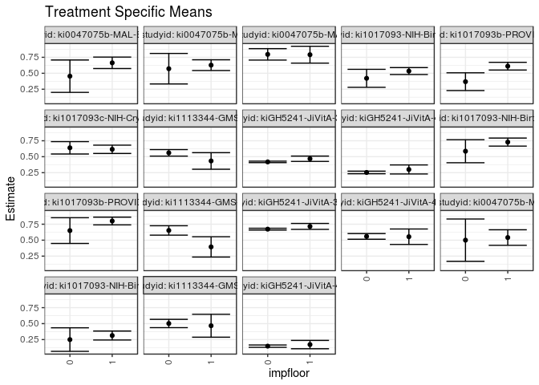

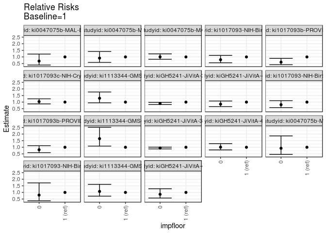

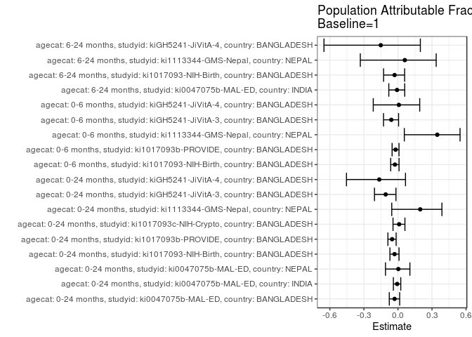

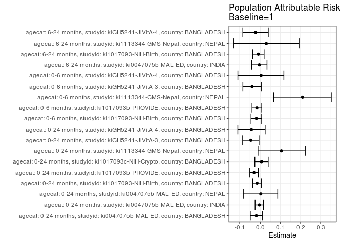

## Results Table

### Parameter: TSM

| agecat | studyid | country | intervention_level | baseline_level | estimate | ci_lower | ci_upper |
| --- | --- | --- | --- | --- | --- | --- | --- |
| 0-24 months | ki0047075b-MAL-ED | BANGLADESH | 1 | NA | 0.6636364 | 0.5737409 | 0.7535318 |
| 0-24 months | ki0047075b-MAL-ED | BANGLADESH | 0 | NA | 0.4545455 | 0.2011212 | 0.7079697 |
| 0-24 months | ki0047075b-MAL-ED | INDIA | 1 | NA | 0.6273292 | 0.5434386 | 0.7112198 |
| 0-24 months | ki0047075b-MAL-ED | INDIA | 0 | NA | 0.5714286 | 0.3326866 | 0.8101705 |
| 0-24 months | ki0047075b-MAL-ED | NEPAL | 1 | NA | 0.7906977 | 0.6589695 | 0.9224259 |
| 0-24 months | ki0047075b-MAL-ED | NEPAL | 0 | NA | 0.7959184 | 0.7066152 | 0.8852215 |
| 0-24 months | ki1017093-NIH-Birth | BANGLADESH | 1 | NA | 0.5346260 | 0.4802983 | 0.5889538 |
| 0-24 months | ki1017093-NIH-Birth | BANGLADESH | 0 | NA | 0.4210526 | 0.2806014 | 0.5615038 |
| 0-24 months | ki1017093b-PROVIDE | BANGLADESH | 1 | NA | 0.6111111 | 0.5507241 | 0.6714981 |
| 0-24 months | ki1017093b-PROVIDE | BANGLADESH | 0 | NA | 0.3684211 | 0.2294489 | 0.5073932 |
| 0-24 months | ki1017093c-NIH-Crypto | BANGLADESH | 1 | NA | 0.6160714 | 0.5509241 | 0.6812187 |
| 0-24 months | ki1017093c-NIH-Crypto | BANGLADESH | 0 | NA | 0.6395349 | 0.5426676 | 0.7364021 |
| 0-24 months | ki1113344-GMS-Nepal | NEPAL | 1 | NA | 0.4337349 | 0.3040214 | 0.5634485 |
| 0-24 months | ki1113344-GMS-Nepal | NEPAL | 0 | NA | 0.5605701 | 0.5093354 | 0.6118047 |
| 0-24 months | kiGH5241-JiVitA-3 | BANGLADESH | 1 | NA | 0.4683544 | 0.4268432 | 0.5098657 |
| 0-24 months | kiGH5241-JiVitA-3 | BANGLADESH | 0 | NA | 0.4190503 | 0.4074899 | 0.4306108 |
| 0-24 months | kiGH5241-JiVitA-4 | BANGLADESH | 1 | NA | 0.3005181 | 0.2296821 | 0.3713542 |
| 0-24 months | kiGH5241-JiVitA-4 | BANGLADESH | 0 | NA | 0.2536116 | 0.2335788 | 0.2736443 |
| 0-6 months | ki1017093-NIH-Birth | BANGLADESH | 1 | NA | 0.7291667 | 0.6663418 | 0.7919916 |
| 0-6 months | ki1017093-NIH-Birth | BANGLADESH | 0 | NA | 0.5862069 | 0.4057286 | 0.7666852 |
| 0-6 months | ki1017093b-PROVIDE | BANGLADESH | 1 | NA | 0.8000000 | 0.7395838 | 0.8604162 |
| 0-6 months | ki1017093b-PROVIDE | BANGLADESH | 0 | NA | 0.6500000 | 0.4484303 | 0.8515697 |
| 0-6 months | ki1113344-GMS-Nepal | NEPAL | 1 | NA | 0.3947368 | 0.2357841 | 0.5536895 |
| 0-6 months | ki1113344-GMS-Nepal | NEPAL | 0 | NA | 0.6524390 | 0.5787947 | 0.7260834 |
| 0-6 months | kiGH5241-JiVitA-3 | BANGLADESH | 1 | NA | 0.7154696 | 0.6689663 | 0.7619729 |
| 0-6 months | kiGH5241-JiVitA-3 | BANGLADESH | 0 | NA | 0.6724811 | 0.6585462 | 0.6864159 |
| 0-6 months | kiGH5241-JiVitA-4 | BANGLADESH | 1 | NA | 0.5538462 | 0.4328908 | 0.6748015 |
| 0-6 months | kiGH5241-JiVitA-4 | BANGLADESH | 0 | NA | 0.5590062 | 0.5146866 | 0.6033258 |
| 6-24 months | ki0047075b-MAL-ED | INDIA | 1 | NA | 0.5411765 | 0.4195451 | 0.6628078 |
| 6-24 months | ki0047075b-MAL-ED | INDIA | 0 | NA | 0.5000000 | 0.1687592 | 0.8312408 |
| 6-24 months | ki1017093-NIH-Birth | BANGLADESH | 1 | NA | 0.3136095 | 0.2434845 | 0.3837345 |
| 6-24 months | ki1017093-NIH-Birth | BANGLADESH | 0 | NA | 0.2500000 | 0.0656374 | 0.4343626 |
| 6-24 months | ki1113344-GMS-Nepal | NEPAL | 1 | NA | 0.4666667 | 0.2873372 | 0.6459962 |
| 6-24 months | ki1113344-GMS-Nepal | NEPAL | 0 | NA | 0.5019455 | 0.4368075 | 0.5670836 |
| 6-24 months | kiGH5241-JiVitA-4 | BANGLADESH | 1 | NA | 0.1718750 | 0.1065288 | 0.2372212 |
| 6-24 months | kiGH5241-JiVitA-4 | BANGLADESH | 0 | NA | 0.1471861 | 0.1289272 | 0.1654451 |

### Parameter: E(Y)

| agecat | studyid | country | intervention_level | baseline_level | estimate | ci_lower | ci_upper |
| --- | --- | --- | --- | --- | --- | --- | --- |
| 0-24 months | ki0047075b-MAL-ED | BANGLADESH | NA | NA | 0.6446281 | 0.5577732 | 0.7314830 |
| 0-24 months | ki0047075b-MAL-ED | INDIA | NA | NA | 0.6228571 | 0.5433246 | 0.7023896 |
| 0-24 months | ki0047075b-MAL-ED | NEPAL | NA | NA | 0.7934783 | 0.7160127 | 0.8709439 |
| 0-24 months | ki1017093-NIH-Birth | BANGLADESH | NA | NA | 0.5191388 | 0.4683286 | 0.5699489 |
| 0-24 months | ki1017093b-PROVIDE | BANGLADESH | NA | NA | 0.5811688 | 0.5245443 | 0.6377934 |
| 0-24 months | ki1017093c-NIH-Crypto | BANGLADESH | NA | NA | 0.6225806 | 0.5684562 | 0.6767051 |
| 0-24 months | ki1113344-GMS-Nepal | NEPAL | NA | NA | 0.5396825 | 0.4917879 | 0.5875772 |
| 0-24 months | kiGH5241-JiVitA-3 | BANGLADESH | NA | NA | 0.4226640 | 0.4115226 | 0.4338055 |
| 0-24 months | kiGH5241-JiVitA-4 | BANGLADESH | NA | NA | 0.2580019 | 0.2386523 | 0.2773515 |
| 0-6 months | ki1017093-NIH-Birth | BANGLADESH | NA | NA | 0.7104072 | 0.6505603 | 0.7702542 |
| 0-6 months | ki1017093b-PROVIDE | BANGLADESH | NA | NA | 0.7837838 | 0.7252863 | 0.8422812 |
| 0-6 months | ki1113344-GMS-Nepal | NEPAL | NA | NA | 0.6039604 | 0.5356875 | 0.6722333 |
| 0-6 months | kiGH5241-JiVitA-3 | BANGLADESH | NA | NA | 0.6757788 | 0.6624235 | 0.6891341 |
| 0-6 months | kiGH5241-JiVitA-4 | BANGLADESH | NA | NA | 0.5583942 | 0.5167799 | 0.6000084 |
| 6-24 months | ki0047075b-MAL-ED | INDIA | NA | NA | 0.5368421 | 0.4223932 | 0.6512910 |
| 6-24 months | ki1017093-NIH-Birth | BANGLADESH | NA | NA | 0.3045685 | 0.2390070 | 0.3701301 |
| 6-24 months | ki1113344-GMS-Nepal | NEPAL | NA | NA | 0.4966887 | 0.4351829 | 0.5581945 |
| 6-24 months | kiGH5241-JiVitA-4 | BANGLADESH | NA | NA | 0.1492734 | 0.1316631 | 0.1668838 |

### Parameter: RR

| agecat | studyid | country | intervention_level | baseline_level | estimate | ci_lower | ci_upper |
| --- | --- | --- | --- | --- | --- | --- | --- |
| 0-24 months | ki0047075b-MAL-ED | BANGLADESH | 1 | 1 | 1.0000000 | 1.0000000 | 1.0000000 |
| 0-24 months | ki0047075b-MAL-ED | BANGLADESH | 0 | 1 | 0.6849315 | 0.3861446 | 1.2149107 |
| 0-24 months | ki0047075b-MAL-ED | INDIA | 1 | 1 | 1.0000000 | 1.0000000 | 1.0000000 |
| 0-24 months | ki0047075b-MAL-ED | INDIA | 0 | 1 | 0.9108911 | 0.5874231 | 1.4124786 |
| 0-24 months | ki0047075b-MAL-ED | NEPAL | 1 | 1 | 1.0000000 | 1.0000000 | 1.0000000 |
| 0-24 months | ki0047075b-MAL-ED | NEPAL | 0 | 1 | 1.0066026 | 0.8227214 | 1.2315819 |
| 0-24 months | ki1017093-NIH-Birth | BANGLADESH | 1 | 1 | 1.0000000 | 1.0000000 | 1.0000000 |
| 0-24 months | ki1017093-NIH-Birth | BANGLADESH | 0 | 1 | 0.7875648 | 0.5556554 | 1.1162643 |
| 0-24 months | ki1017093b-PROVIDE | BANGLADESH | 1 | 1 | 1.0000000 | 1.0000000 | 1.0000000 |
| 0-24 months | ki1017093b-PROVIDE | BANGLADESH | 0 | 1 | 0.6028708 | 0.4082085 | 0.8903618 |
| 0-24 months | ki1017093c-NIH-Crypto | BANGLADESH | 1 | 1 | 1.0000000 | 1.0000000 | 1.0000000 |
| 0-24 months | ki1017093c-NIH-Crypto | BANGLADESH | 0 | 1 | 1.0380856 | 0.8626326 | 1.2492244 |
| 0-24 months | ki1113344-GMS-Nepal | NEPAL | 1 | 1 | 1.0000000 | 1.0000000 | 1.0000000 |
| 0-24 months | ki1113344-GMS-Nepal | NEPAL | 0 | 1 | 1.2924254 | 0.9454769 | 1.7666889 |
| 0-24 months | kiGH5241-JiVitA-3 | BANGLADESH | 1 | 1 | 1.0000000 | 1.0000000 | 1.0000000 |
| 0-24 months | kiGH5241-JiVitA-3 | BANGLADESH | 0 | 1 | 0.8947291 | 0.8154132 | 0.9817602 |
| 0-24 months | kiGH5241-JiVitA-4 | BANGLADESH | 1 | 1 | 1.0000000 | 1.0000000 | 1.0000000 |
| 0-24 months | kiGH5241-JiVitA-4 | BANGLADESH | 0 | 1 | 0.8439143 | 0.6581689 | 1.0820800 |
| 0-6 months | ki1017093-NIH-Birth | BANGLADESH | 1 | 1 | 1.0000000 | 1.0000000 | 1.0000000 |
| 0-6 months | ki1017093-NIH-Birth | BANGLADESH | 0 | 1 | 0.8039409 | 0.5839539 | 1.1068012 |
| 0-6 months | ki1017093b-PROVIDE | BANGLADESH | 1 | 1 | 1.0000000 | 1.0000000 | 1.0000000 |
| 0-6 months | ki1017093b-PROVIDE | BANGLADESH | 0 | 1 | 0.8125000 | 0.5904824 | 1.1179948 |
| 0-6 months | ki1113344-GMS-Nepal | NEPAL | 1 | 1 | 1.0000000 | 1.0000000 | 1.0000000 |
| 0-6 months | ki1113344-GMS-Nepal | NEPAL | 0 | 1 | 1.6528455 | 1.0879522 | 2.5110463 |
| 0-6 months | kiGH5241-JiVitA-3 | BANGLADESH | 1 | 1 | 1.0000000 | 1.0000000 | 1.0000000 |
| 0-6 months | kiGH5241-JiVitA-3 | BANGLADESH | 0 | 1 | 0.9399156 | 0.8779328 | 1.0062745 |
| 0-6 months | kiGH5241-JiVitA-4 | BANGLADESH | 1 | 1 | 1.0000000 | 1.0000000 | 1.0000000 |
| 0-6 months | kiGH5241-JiVitA-4 | BANGLADESH | 0 | 1 | 1.0093168 | 0.8000639 | 1.2732987 |
| 6-24 months | ki0047075b-MAL-ED | INDIA | 1 | 1 | 1.0000000 | 1.0000000 | 1.0000000 |
| 6-24 months | ki0047075b-MAL-ED | INDIA | 0 | 1 | 0.9239130 | 0.4590405 | 1.8595643 |
| 6-24 months | ki1017093-NIH-Birth | BANGLADESH | 1 | 1 | 1.0000000 | 1.0000000 | 1.0000000 |
| 6-24 months | ki1017093-NIH-Birth | BANGLADESH | 0 | 1 | 0.7971698 | 0.3690609 | 1.7218829 |
| 6-24 months | ki1113344-GMS-Nepal | NEPAL | 1 | 1 | 1.0000000 | 1.0000000 | 1.0000000 |
| 6-24 months | ki1113344-GMS-Nepal | NEPAL | 0 | 1 | 1.0755976 | 0.7171414 | 1.6132244 |
| 6-24 months | kiGH5241-JiVitA-4 | BANGLADESH | 1 | 1 | 1.0000000 | 1.0000000 | 1.0000000 |
| 6-24 months | kiGH5241-JiVitA-4 | BANGLADESH | 0 | 1 | 0.8563558 | 0.5740733 | 1.2774417 |

### Parameter: PAR

| agecat | studyid | country | intervention_level | baseline_level | estimate | ci_lower | ci_upper |
| --- | --- | --- | --- | --- | --- | --- | --- |
| 0-24 months | ki0047075b-MAL-ED | BANGLADESH | 1 | NA | -0.0190083 | -0.0482288 | 0.0102123 |
| 0-24 months | ki0047075b-MAL-ED | INDIA | 1 | NA | -0.0044720 | -0.0248142 | 0.0158701 |
| 0-24 months | ki0047075b-MAL-ED | NEPAL | 1 | NA | 0.0027806 | -0.0824301 | 0.0879912 |
| 0-24 months | ki1017093-NIH-Birth | BANGLADESH | 1 | NA | -0.0154873 | -0.0362226 | 0.0052480 |
| 0-24 months | ki1017093b-PROVIDE | BANGLADESH | 1 | NA | -0.0299423 | -0.0508244 | -0.0090601 |
| 0-24 months | ki1017093c-NIH-Crypto | BANGLADESH | 1 | NA | 0.0065092 | -0.0261204 | 0.0391388 |
| 0-24 months | ki1113344-GMS-Nepal | NEPAL | 1 | NA | 0.1059476 | -0.0107530 | 0.2226482 |
| 0-24 months | kiGH5241-JiVitA-3 | BANGLADESH | 1 | NA | -0.0456904 | -0.0856236 | -0.0057572 |
| 0-24 months | kiGH5241-JiVitA-4 | BANGLADESH | 1 | NA | -0.0425162 | -0.1092339 | 0.0242015 |
| 0-6 months | ki1017093-NIH-Birth | BANGLADESH | 1 | NA | -0.0187594 | -0.0446391 | 0.0071202 |
| 0-6 months | ki1017093b-PROVIDE | BANGLADESH | 1 | NA | -0.0162162 | -0.0398277 | 0.0073953 |
| 0-6 months | ki1113344-GMS-Nepal | NEPAL | 1 | NA | 0.2092236 | 0.0663210 | 0.3521261 |
| 0-6 months | kiGH5241-JiVitA-3 | BANGLADESH | 1 | NA | -0.0396908 | -0.0845142 | 0.0051325 |
| 0-6 months | kiGH5241-JiVitA-4 | BANGLADESH | 1 | NA | 0.0045480 | -0.1089917 | 0.1180877 |
| 6-24 months | ki0047075b-MAL-ED | INDIA | 1 | NA | -0.0043344 | -0.0419154 | 0.0332466 |
| 6-24 months | ki1017093-NIH-Birth | BANGLADESH | 1 | NA | -0.0090409 | -0.0370914 | 0.0190095 |
| 6-24 months | ki1113344-GMS-Nepal | NEPAL | 1 | NA | 0.0300221 | -0.1322993 | 0.1923435 |
| 6-24 months | kiGH5241-JiVitA-4 | BANGLADESH | 1 | NA | -0.0226016 | -0.0847193 | 0.0395162 |

### Parameter: PAF

| agecat | studyid | country | intervention_level | baseline_level | estimate | ci_lower | ci_upper |
| --- | --- | --- | --- | --- | --- | --- | --- |
| 0-24 months | ki0047075b-MAL-ED | BANGLADESH | 1 | NA | -0.0294872 | -0.0762681 | 0.0152603 |
| 0-24 months | ki0047075b-MAL-ED | INDIA | 1 | NA | -0.0071799 | -0.0403006 | 0.0248863 |
| 0-24 months | ki0047075b-MAL-ED | NEPAL | 1 | NA | 0.0035043 | -0.1100031 | 0.1054046 |
| 0-24 months | ki1017093-NIH-Birth | BANGLADESH | 1 | NA | -0.0298326 | -0.0707562 | 0.0095268 |
| 0-24 months | ki1017093b-PROVIDE | BANGLADESH | 1 | NA | -0.0515208 | -0.0884251 | -0.0158678 |
| 0-24 months | ki1017093c-NIH-Crypto | BANGLADESH | 1 | NA | 0.0104552 | -0.0434438 | 0.0615701 |
| 0-24 months | ki1113344-GMS-Nepal | NEPAL | 1 | NA | 0.1963147 | -0.0545799 | 0.3875190 |
| 0-24 months | kiGH5241-JiVitA-3 | BANGLADESH | 1 | NA | -0.1081010 | -0.2067570 | -0.0175104 |
| 0-24 months | kiGH5241-JiVitA-4 | BANGLADESH | 1 | NA | -0.1647902 | -0.4535566 | 0.0666093 |
| 0-6 months | ki1017093-NIH-Birth | BANGLADESH | 1 | NA | -0.0264066 | -0.0637859 | 0.0096593 |
| 0-6 months | ki1017093b-PROVIDE | BANGLADESH | 1 | NA | -0.0206897 | -0.0514932 | 0.0092115 |
| 0-6 months | ki1113344-GMS-Nepal | NEPAL | 1 | NA | 0.3464193 | 0.0561508 | 0.5474195 |
| 0-6 months | kiGH5241-JiVitA-3 | BANGLADESH | 1 | NA | -0.0587335 | -0.1272203 | 0.0055923 |
| 0-6 months | kiGH5241-JiVitA-4 | BANGLADESH | 1 | NA | 0.0081448 | -0.2175316 | 0.1919908 |
| 6-24 months | ki0047075b-MAL-ED | INDIA | 1 | NA | -0.0080738 | -0.0805275 | 0.0595215 |
| 6-24 months | ki1017093-NIH-Birth | BANGLADESH | 1 | NA | -0.0296844 | -0.1265874 | 0.0588835 |
| 6-24 months | ki1113344-GMS-Nepal | NEPAL | 1 | NA | 0.0604444 | -0.3316015 | 0.3370654 |
| 6-24 months | kiGH5241-JiVitA-4 | BANGLADESH | 1 | NA | -0.1514104 | -0.6520450 | 0.1975123 |